# Amyloid Positivity Exploration

## Motivation/Goal

This project was created over the span of a week long ML hackathon held virtually at UCI. Hackathon End Date: 04/25/2020

Our main research question we focused our efforts on addressing was predicting which people tested Amyloid Positive based on other features in the dataset. For context, Amyloid Beta, the cerebrospinal fluid measurement taken at the time of assessment (or within 6 months of assessment) are believed to be one of the first indicators of otherwise pre-symptomatic Alzheimer’s disease. Amyloid Positivity diagnosis is then determined according to the evidence-based cutoff of 192 pg/mL. Amyloid Beta levels below 192 pg/mL is considered Amyloid Positive, while above 192 pg/mL is considered Amyloid Negative. Some other topics of analysis we explored inlcluded predicting future test scores with past test scores, investigating the existance of different clusters or subgroups within the data, and thoroughly understanding the relationship between combinations of different features.

### Libraries

```r
library(aod)
library(caret)
library(ggplot2)
library(InformationValue)
library(psychotree)
library(reshape2)
library(smbinning)
library(tidyverse)
```

### Raw Data

Unprocessed data from 292 patients provided by the Alzheimer’s Disease Neuroimaging Initiative. There are 939 assessments represented in terms of 19 variables from the AVLTAmyloidClassification dataset.

##### Demographics:

- Age
- Sex
- Years of Education

##### Protocol Information:

- Time Since Baseline Test (Month 0)

##### Memory Test Outcomes:

- Free Recall Scores
- Recognition Scores

##### Biomarkers:

- APOE Genotype
- Beta Amyloid

##### Diagnosis of Memory Impairment:

- Cognitively Normal/Impaired

```r
amyloid <- read_csv('./Data/Amyloid.csv')
```

### Summary Statisitics

Our data at a glance. Continuous features are summarized as means, while the categorical features are summarized as proportions.

#### A. Demographics:

```
## # A tibble: 1 x 4
##   mean_age mean_edu prop_male prop_female
##      <dbl>    <dbl>     <dbl>       <dbl>
## 1     75.1     15.8     0.622       0.378
```

#### B. Protocol Information:

[output not shown]

#### C. Memory Test Outcomes:

```
## # A tibble: 2 x 8
##   abeta6mcut mean_t1sum mean_t2sum mean_t3sum mean_t4sum mean_t5sum mean_t6sum
##        <dbl>      <dbl>      <dbl>      <dbl>      <dbl>      <dbl>      <dbl>
## 1          1       4.67       6.98       8.42       9.30      10          6.61
## 2          2       4.30       5.67       6.78       7.43       7.74       4.20
## # ... with 1 more variable: mean_t7sum <dbl>
```

#### D. Biomarkers:

```
## # A tibble: 1 x 9
##   mean_abeta6_mea~ prop_negative prop_positive prop_e2e2 prop_e2e3 prop_e3e3
##              <dbl>         <dbl>         <dbl>     <dbl>     <dbl>     <dbl>
## 1             180.         0.396         0.604         0    0.0919     0.484
## # ... with 3 more variables: prop_e2e4 <dbl>, prop_e3e4 <dbl>, prop_e4e4 <dbl>
```

#### E. Diagnosis of Memory Impairment

```
## # A tibble: 1 x 3
##   prop_normal_cognition prop_subjectively_impaired prop_objectively_impaired
##                   <dbl>                      <dbl>                     <dbl>
## 1                 0.378                     0.0141                     0.608
```

## Preprocessing

For preprocessing we:

```r
amyloid <- amyloid %>%
  mutate(
    month = as.factor(if_else(month < 0, NA_real_, month)),
    abeta6m = if_else(abeta6m < 0, NA_real_, abeta6m),
    abeta6mcut = factor(abeta6mcut),
    sex = factor(sex),
    genotype = factor(genotype),
    dx = factor(dx),
    edu = if_else(edu < 0, NA_real_, edu),
    wordlist = factor(wordlist),
    t1sum = if_else(t1sum < 0, NA_real_, t1sum),
    t2sum = if_else(t2sum < 0, NA_real_, t2sum),
    t3sum = if_else(t3sum < 0, NA_real_, t3sum),
    t4sum = if_else(t4sum < 0, NA_real_, t4sum),
    t5sum = if_else(t5sum < 0, NA_real_, t5sum),
    t6sum = if_else(t6sum < 0, NA_real_, t6sum),
    t7sum = if_else(t7sum < 0, NA_real_, t7sum),
    distsum = if_else(distsum < 0, NA_real_, distsum),
    drec_hits = if_else(drec_hits < 0, NA_real_, drec_hits),
    drec_fa = if_else(drec_fa < 0, NA_real_, drec_fa),
    t1t2 = t2sum - t1sum,
    t2t3 = t3sum - t2sum,
    t3t4 = t4sum - t3sum,
    t4t5 = t5sum - t4sum,
    t5t6 = t6sum - t5sum,
    t6t7 = t7sum - t6sum,
    t1t5 = t5sum - t1sum,
    t5t7 = t7sum - t5sum,
    recognition_prop = drec_hits/drec_fa
  )

  baseline <- amyloid %>% filter(month == 0)
```

## Exploratory Data Analysis (EDA)

#### Exploring the association of Demographic/Biomarker/Diagnosis features with Performance Measures and Amyloid Beta Measures.

##### Inference:

- Genotype is a discriminatory factor when predicting Beta Amyloid
- Because sex is correlated with AVLT scores, but not Amyloid Beta levels, including sex into a linear model would introduce multicollinearity

#### A. Genotype

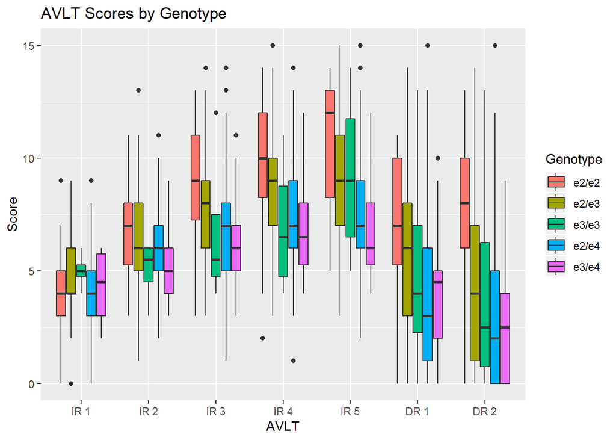

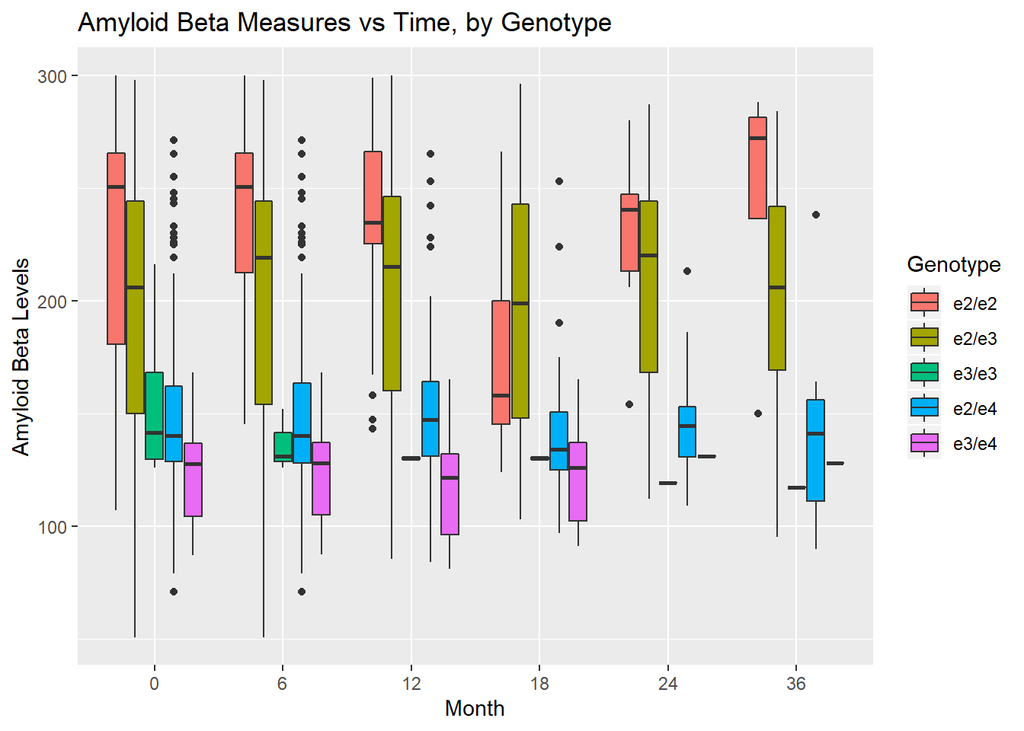

#### B. Sex

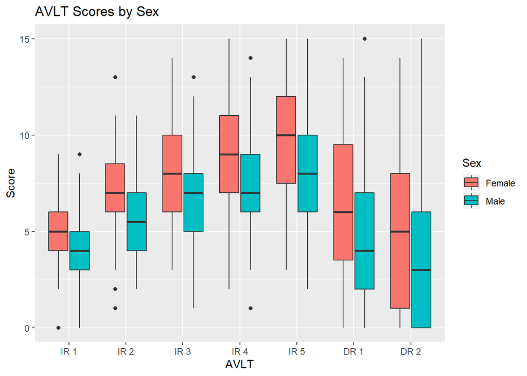

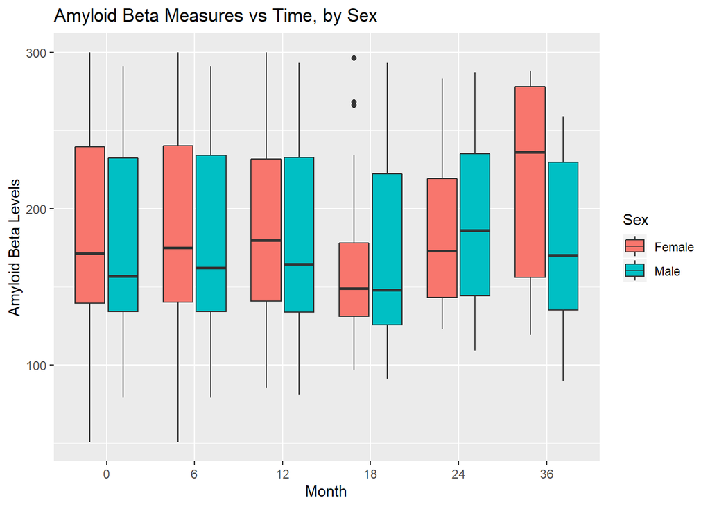

#### C. Education

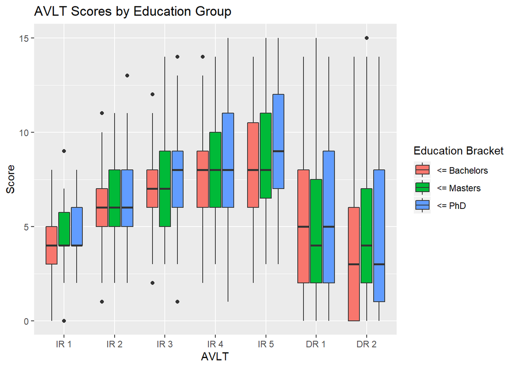

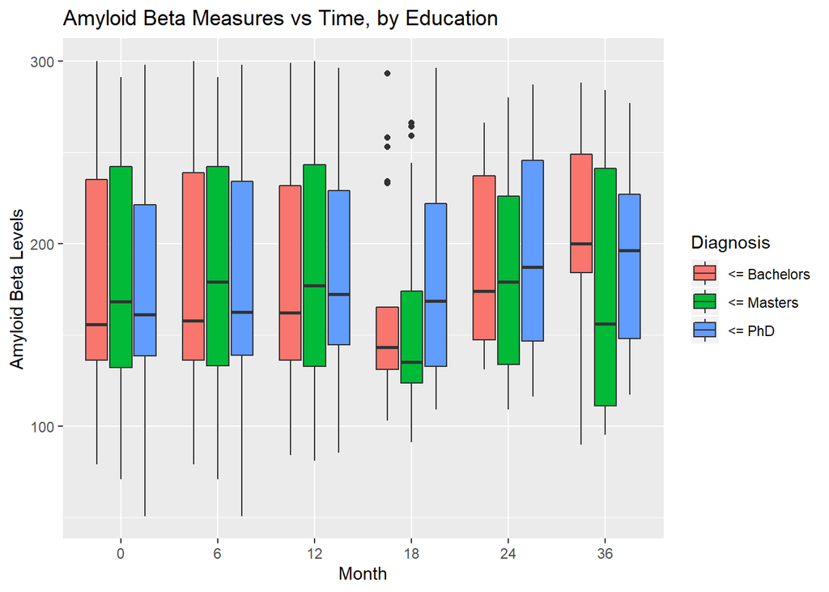

#### D. Age

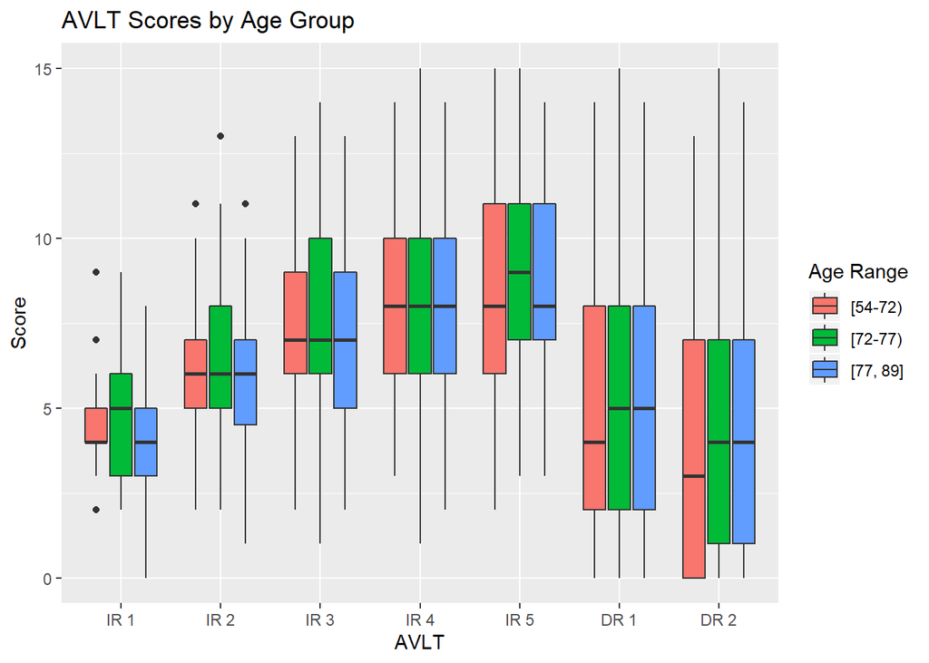

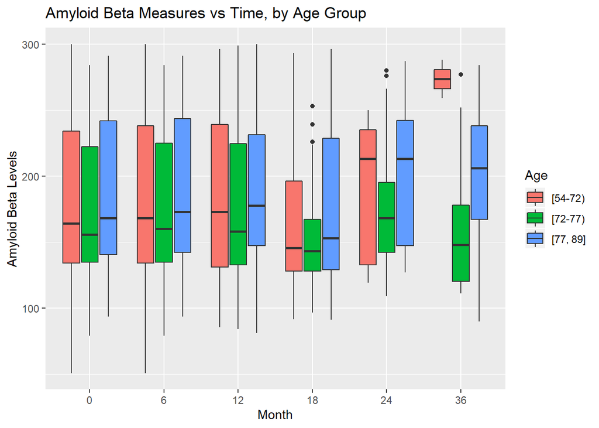

#### E. Diagnosis

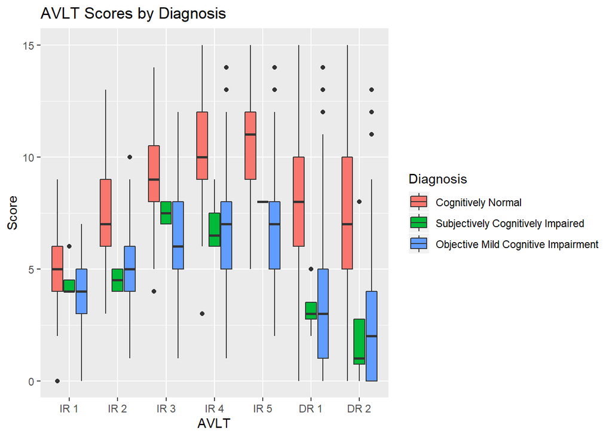

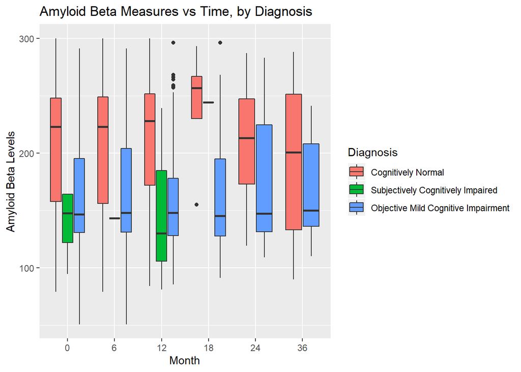

#### Exploring how various performance measures and their linear combinations are associated with Amyloid Positivity

##### Key Observations:

- Delta measure between scores on successive administrations of the immediate recall tasks did not vary much by Amyloid Positivity
- Overall change in performance across the immediate recall tasks (t5sum - t1sum) was noticeably different across Amyloid Positive and Negative Participants
- The ratio of hits to false alarms on the Recognition task seems to be greater for those who tested Amyloid Postive

##### Inference:

- The learning effect accross the immediate recall discriminates between Amyloid Postive and Negative participants far better than the individual test measures

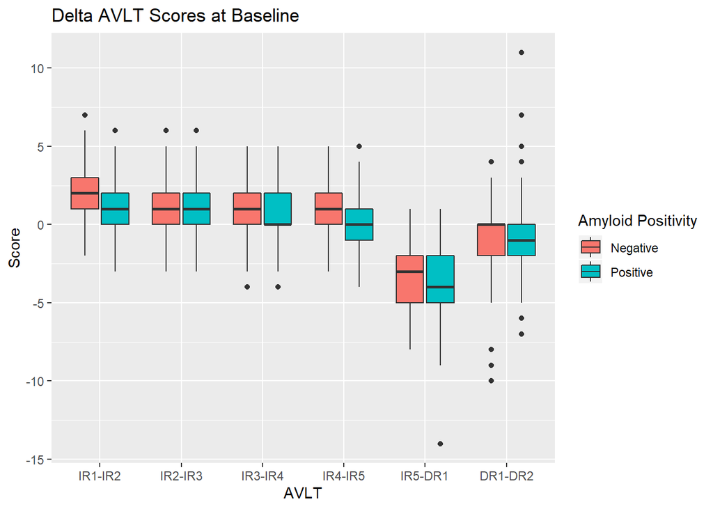

```
##              Score               drec amyloid_positivity
##          "numeric"        "character"        "character"
```

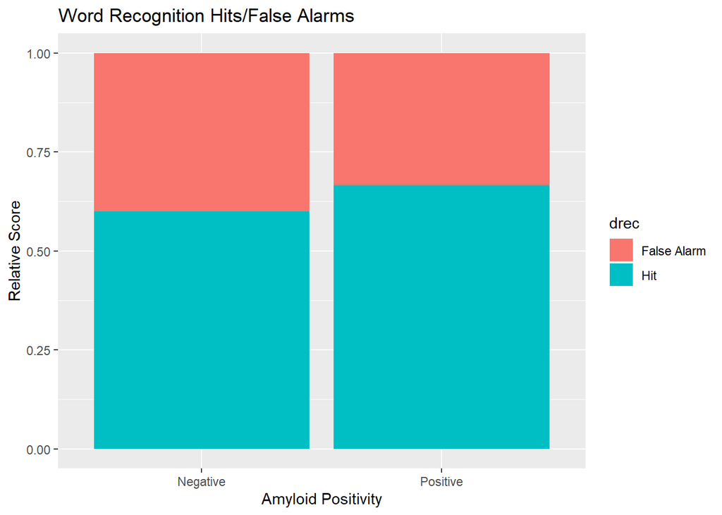

## Question 1:

### Cluster Participants based on Recognition Task Performance using

Participants were given a **recognition task** of idetifying the old and new words from a list of 30 words written on a sheet of paper. This list was composed of all the words on the word list used as a part of the Immediate and Delayed Recall tasks in addition to 15 “new” words. The respondent has to identify all of the words from recall word list by circling them. The correctly recognized “old words” were counted as `drec_hits`, while the number of “new” words incorrectly identified as “old” were recored as `drec_fa`. From these two values, in addition to the total number of words on the “old” and “new” lists, we were able to compute the total number of false and true postitives for the “old” and “new” lists as follows:

- `old_old = drec_hits` : Number of “old” words correctly identified as “old”
- `old_new = 15 - drec_hits` : Number of “old” words incorrectly identified as “new”
- `new_new = 15 - drec_fa` : Number of “new” words correctly identified as “new”
- `new_old = drec_fa` : Number of “new” words incorrectly identified as “old”

We modelled the cognitive process used by all the participants as a **One High Threshold** model as shown below:

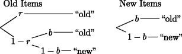

One High Threshold Spec

Using ** _ recursive partitioning _ ** on Multinomial Processing Trees we modelled the parameters **r** and **b** as functions of various covariates in our data.

- $$r = P(recognizing a previously presented word)$$
- $$b = P(randomly guessing that a word was previously presented)$$

```r
# Baseline participants who have taken the Recognition Test
amyloid_mpt_data <- baseline %>%
  filter(!is.na(drec_hits) | !is.na(drec_fa)) %>%
  select(sex, age, t1t5, t5t6, t5t7, dx, genotype, drec_fa, drec_hits, abeta6m)

# Creating count matrix of true positives, false positives, true negatives, and false negatives
# on the recognition-memory experiments
y <- as.matrix(
  cbind(
    old_old = amyloid_mpt_data$drec_hits,
    old_new = 15-amyloid_mpt_data$drec_hits,
    new_old = amyloid_mpt_data$drec_fa,
    new_new = 15-amyloid_mpt_data$drec_fa
    )
  )
```

#### Immediate Recall Learning Effect (T5-T1)

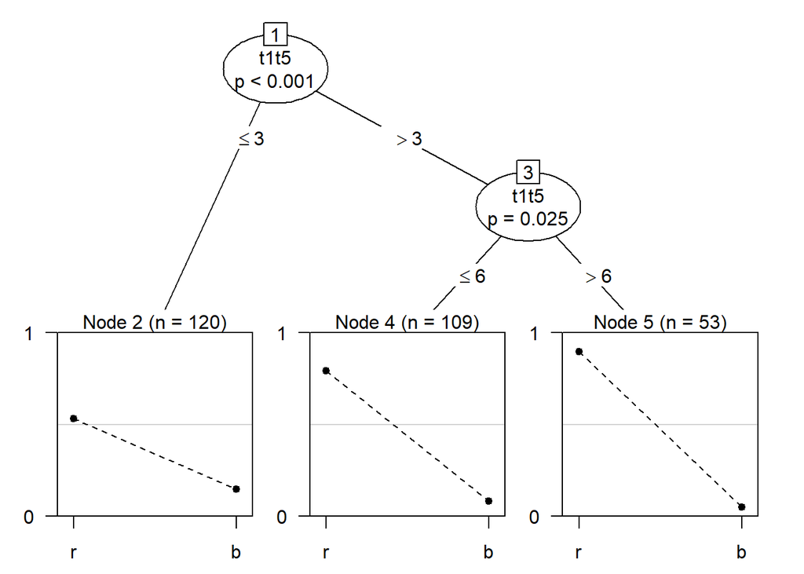

```r
  # learning (T5 - T1 scores)
  amyloid_tree_learning <- mpttree(y ~ t1t5, data = amyloid_mpt_data, spec = mptspec("1HT"))
  plot(amyloid_tree_learning, index = c("r", "b"))
```

#### Age

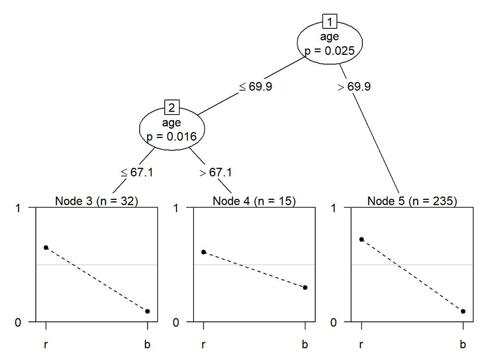

```r
  # age
  amyloid_tree_age <- mpttree(y ~ age, data = amyloid_mpt_data, spec = mptspec("1HT"))
  plot(amyloid_tree_age, index = c("r", "b"))
```

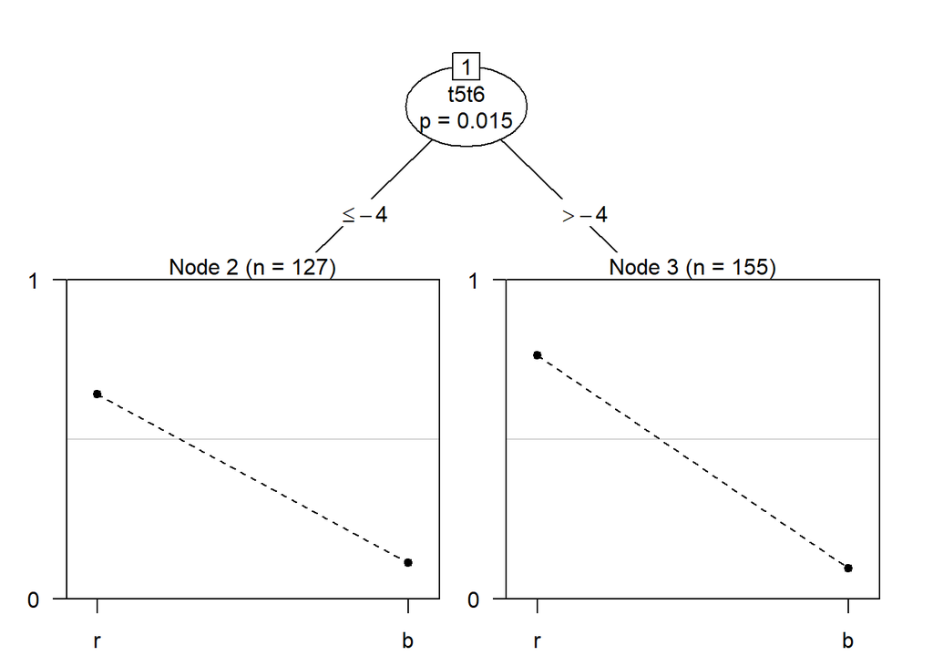

```r
  # interference effect (T6 - T5)
  amyloid_tree_interference <- mpttree(y ~ t5t6, data = amyloid_mpt_data, spec = mptspec("1HT"))
  plot(amyloid_tree_interference, index = c("r", "b"))
```

#### Sex

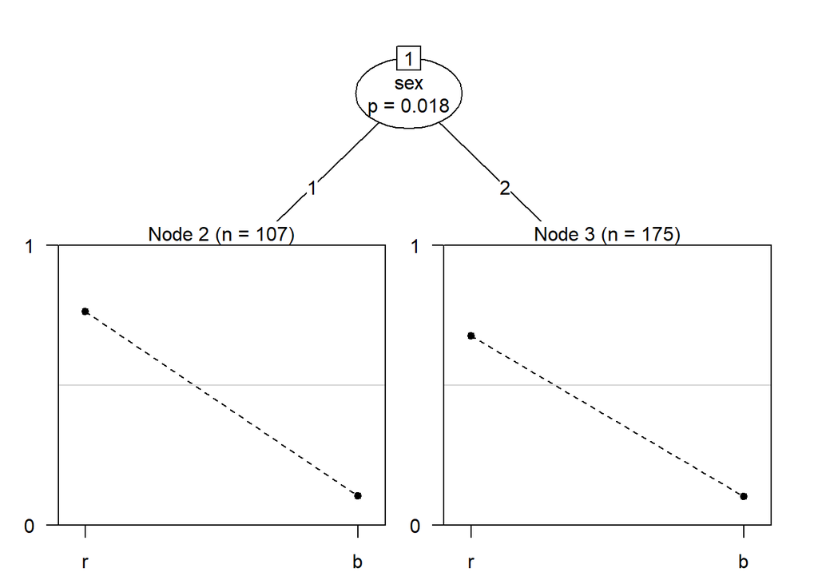

```r
  # sex
  amyloid_tree_sex <- mpttree(y ~ sex, data = amyloid_mpt_data, spec = mptspec("1HT"))
  plot(amyloid_tree_sex, index = c("r", "b"))
```

#### Diagnosis

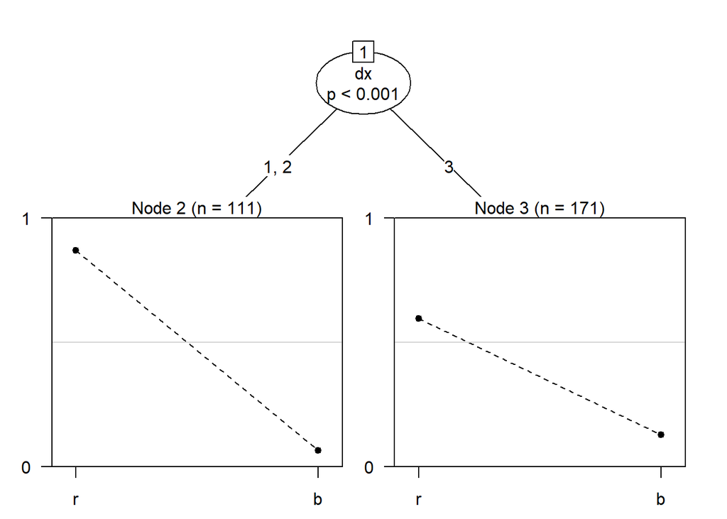

```r
  # dx
  amyloid_tree_dx <- mpttree(y ~ dx, data = amyloid_mpt_data, spec = mptspec("1HT"))
  plot(amyloid_tree_dx, index = c("r", "b"))
```

#### Genotype

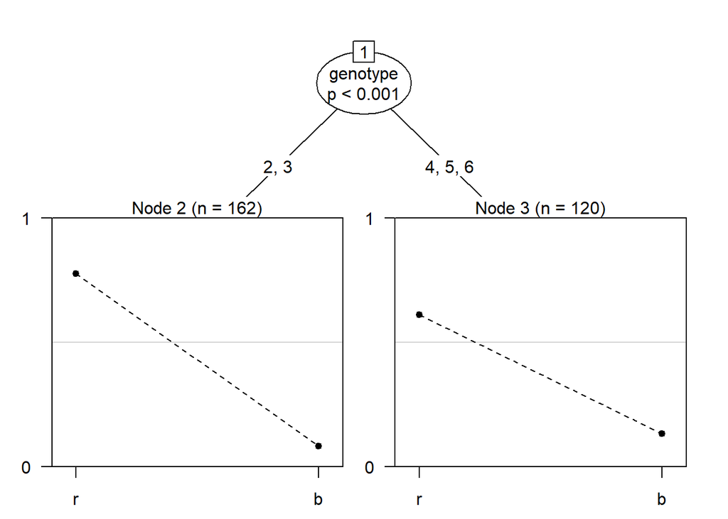

```r
  # genotype
  amyloid_tree_genotype <- mpttree(y ~ genotype, data = amyloid_mpt_data, spec = mptspec("1HT"))
  plot(amyloid_tree_genotype, index = c("r", "b"))
```

#### Full Model

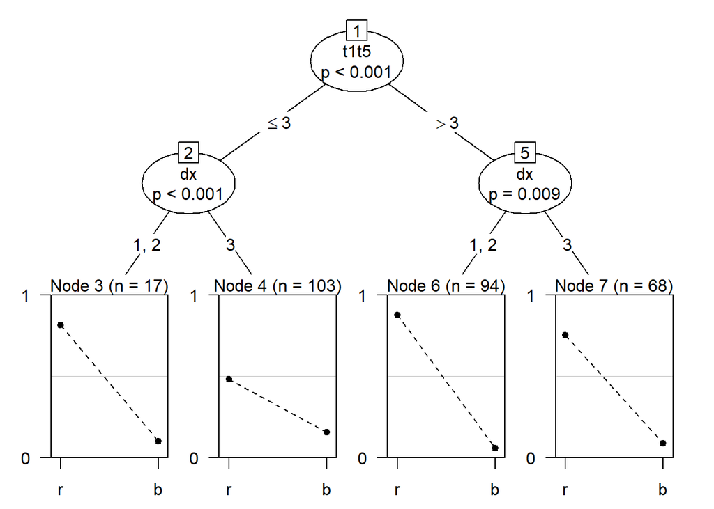

```r
  # full model
  amyloid_tree_all <- mpttree(y ~ sex + age + t1t5 + t5t6 + t5t7 + dx + genotype, data = amyloid_mpt_data, spec = mptspec("1HT"))
  plot(amyloid_tree_all, index = c("r", "b"))
```

#### Amyloid Beta Measure

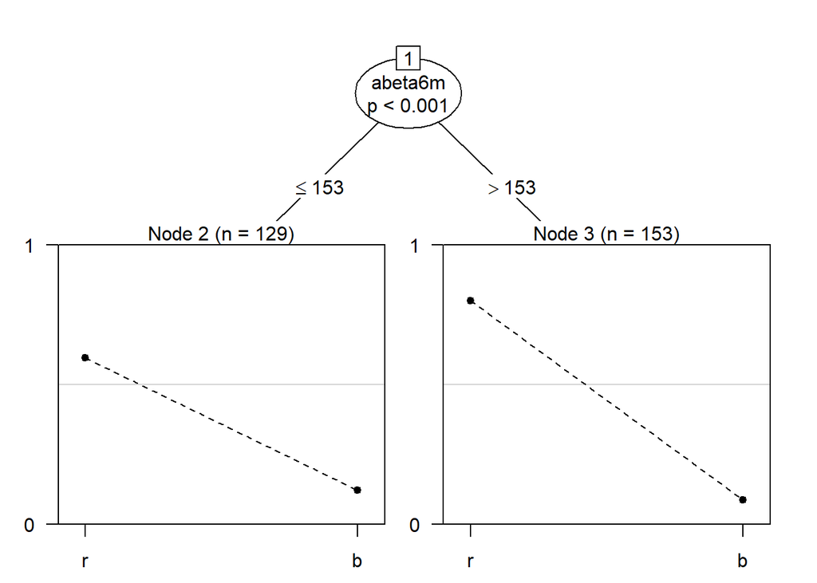

```r
  # amyloid beta measure
  amyloid_tree_all <- mpttree(y ~ abeta6m, data = amyloid_mpt_data, spec = mptspec("1HT"))
  plot(amyloid_tree_all, index = c("r", "b"))
```

### Insights:

#### Main Takeaway: Use the categories generated by the MPTs to create additional features that we could incorporate into our classification model for the task of predicting Amyloid Positivity.

## Question 2:

### Predict Amyloid Positivity with Feature Selection

#### Correlation Matrix

By generating a correlation matrix, we were able to highlight features that had a high corrolation with Amyloid Beta values. The features displayed in this correlation matrix are all of our continuous feature values.

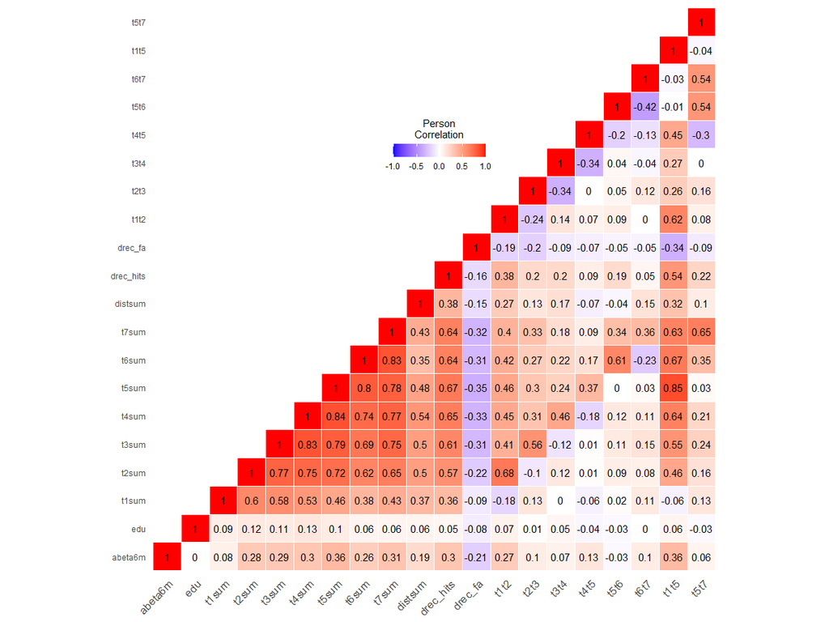

#### Logistic Regression Model

We made two models to compare:

- Baseline: t1t5
- Full: t1t5 + dx + genotype

```r
# Split data by Amyloid Positivity
logit_amyloid <- baseline %>%
  mutate(abeta6mcut = as.factor(if_else(abeta6mcut == 1, 0, 1)))

abeta_neg <- logit_amyloid %>% filter(abeta6mcut == 0)
abeta_pos <- logit_amyloid %>% filter(abeta6mcut == 1)

# Create Test-Train Split
abeta_neg_training_rows <- sample(1:nrow(abeta_neg), 0.7*nrow(abeta_neg))  # neg for train pos
abeta_pos_training_rows <- sample(1:nrow(abeta_pos), 0.7*nrow(abeta_neg))  # pos for training. Pick as many pos as neg
training_pos <- abeta_pos[abeta_pos_training_rows, ]
training_neg <- abeta_neg[abeta_neg_training_rows, ]
trainingData <- rbind(training_neg, training_pos)  # row bind the negitives and positives

test_pos <- abeta_pos[-abeta_pos_training_rows, ]
test_neg <- abeta_neg[-abeta_neg_training_rows, ]
testData <- rbind(test_neg, test_pos)  # row bind the neg and pos

# Build logistic regression models

# Test
logit_baseline <- glm(abeta6mcut ~ t1t5, data=trainingData, family=binomial(link="logit"))
predicted_baseline <- plogis(predict(logit_baseline, testData))  # predicted scores
optCutOff_baseline <- optimalCutoff(testData$abeta6mcut, predicted_baseline)[1]

# Learning, Genotype, Diagnosis
logit_full <- glm(abeta6mcut ~ t1t5 + genotype + dx, data=trainingData, family=binomial(link="logit"))
predicted_full <- plogis(predict(logit_full, testData))  # predicted scores
optCutOff_full <- optimalCutoff(testData$abeta6mcut, predicted_full)[1]
```

#### Evaluation

Left Plot: Baseline Model

Right Plot: Full Model

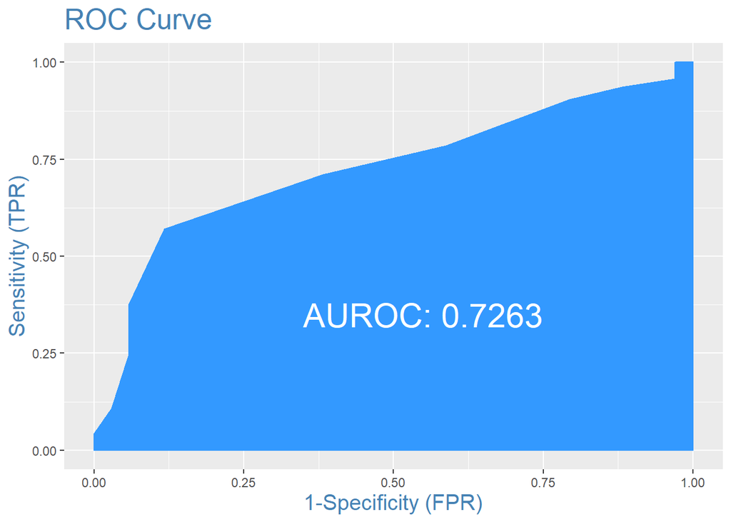

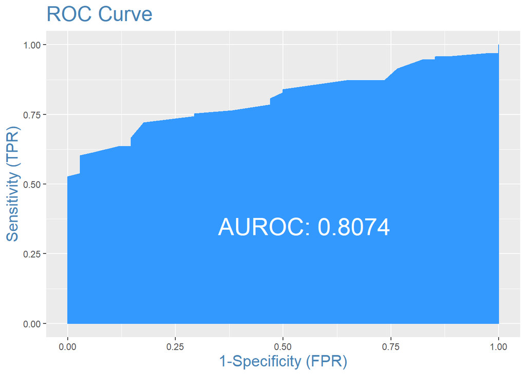

#### Model Diaognostics and Comparisons

As an experiment, we tried different combinations of features not shown below and found that adding sex or education actually lowered the AUC score.

##### A. Model Diagnostics

Baseline Model

```
##
## Call:
## glm(formula = abeta6mcut ~ t1t5, family = binomial(link = "logit"),
##     data = trainingData)
##
## Deviance Residuals:
##      Min        1Q    Median        3Q       Max
## -1.72204  -1.11235   0.04203   1.01408   1.86023
##
## Coefficients:
##             Estimate Std. Error z value Pr(>|z|)
## (Intercept)  1.22522    0.34477   3.554  0.00038 ***
## t1t5        -0.27604    0.06829  -4.042  5.3e-05 ***
## ---
## Signif. codes:  0 '***' 0.001 '**' 0.01 '*' 0.05 '.' 0.1 ' ' 1
##
## (Dispersion parameter for binomial family taken to be 1)
##
##     Null deviance: 216.26  on 155  degrees of freedom
## Residual deviance: 197.28  on 154  degrees of freedom
## AIC: 201.28
##
## Number of Fisher Scoring iterations: 4
```

Full Model

```
##
## Call:
## glm(formula = abeta6mcut ~ t1t5 + genotype + dx, family = binomial(link = "logit"),
##     data = trainingData)
##
## Deviance Residuals:
##      Min        1Q    Median        3Q       Max
## -1.96963  -0.80184  -0.00011   0.94139   1.92759
##
## Coefficients:
##               Estimate Std. Error z value Pr(>|z|)
## (Intercept)   -1.58458    0.95896  -1.652  0.09846 .
## t1t5          -0.10866    0.08142  -1.334  0.18204
## genotype3      1.15808    0.81099   1.428  0.15330
## genotype4    -16.31252 3956.18041  -0.004  0.99671
## genotype5      2.49478    0.85400   2.921  0.00349 **
## genotype6     18.20121 1438.93931   0.013  0.98991
## dx2           17.22881 1974.27099   0.009  0.99304
## dx3            0.87433    0.42046   2.079  0.03757 *
## ---
## Signif. codes:  0 '***' 0.001 '**' 0.01 '*' 0.05 '.' 0.1 ' ' 1
##
## (Dispersion parameter for binomial family taken to be 1)
##
##     Null deviance: 216.26  on 155  degrees of freedom
## Residual deviance: 163.90  on 148  degrees of freedom
## AIC: 179.9
##
## Number of Fisher Scoring iterations: 16
```

##### B. Misclassification Error (Lower the Better)

Baseline Model

```
## [1] 0.2598
```

Full Model

```
## [1] 0.252
```

##### C. True Positive Rate

Baseline Model

```
## [1] 1
```

Full Model

```
## [1] 0.8387097
```

##### D. False Positive Rate

Baseline Model

[output not shown]

Full Model

```
## [1] 0.5
```

##### E. Confusion Matrix (Columns=Actual, Rows=Predicted)

Baseline Model

```
##    0  1
## 0  1  0
## 1 33 93
```

Full Model

```
##    0  1
## 0 17 15
## 1 17 78
```

## Question 3:

### [Future Work] Predict test score trajectory in a single visit

For future work, we wanted to use a Linear Mixed-Effects Model (LME) to predict a patient’s AVLT scores for future visits, based on their past visits. Unfortunately, due to time contraints, we did not complete our model before the hackathon deadline and were not able to evaluate our results in time.

##### Details:

- Target (what we want to predict): AVLT scores (t1sum, t2sum, …, t1t5, …)
- Fixed Effects (features that do not change over time): Demographics, Biomarkers, etc.
- Random Effects (variable features that change over time): Time from Baseline Visit (Month = 0), Interactions between month and AVLT score

##### Experiments

Something interesting we noticed after looking through our EDA was that females on average tend to get higher AVLT scores than males. We plan on taking this bias into account when training our model and comparing the results to a model that does not account for this bias.